# MSfragger with Cluster Profiler compare HeLa and K562 standards

Brett S Phinney, PhD. UC Davis Genome Center Proteomics Core

# Warning. This notebook is not well documented at all. If you want to see some nice notebooks, look here

https://github.com/pwilmart/TMT_analysis_examples

This is a simple notebook that takes the results from MSFraggers protein file and does Gene ontology enrichment using the library ClusterProfiler

files:

1: is a 100 ng hela digest standard from Pierce analyzed on our timsTOfPro using a 90 minute gradient

https://www.thermofisher.com/order/catalog/product/88328#/88328

2: is a 100 ng K562 digest standard from Promega analyzed on our timsTOfPro using a 30 minute gradient

https://www.promega.com/products/mass-spectrometry/mass-spec-reference-reagents/mass-spec-compatible-yeast-and-human-protein-extracts/?catNum=V6951

These are just 2 random files I pulled to test this . Plus I thought it would be cool to see differences between K562 and HeLa

```r
# load Libraries (install if necessary)

packages = c("BiocManager","tidyverse","clusterProfiler","org.Hs.eg.db")

package.check <- lapply(packages, FUN = function(x) {
    if (!require(x, character.only = TRUE)) {
        install.packages(x, dependencies = TRUE)
        library(x, character.only = TRUE)
    }
})
```

```
Bioconductor version 3.10 (BiocManager 1.30.10), ?BiocManager::install for help
clusterProfiler v3.14.0  For help: https://guangchuangyu.github.io/software/clusterProfiler

If you use clusterProfiler in published research, please cite:
Guangchuang Yu, Li-Gen Wang, Yanyan Han, Qing-Yu He. clusterProfiler: an R package for comparing biological themes among gene clusters. OMICS: A Journal of Integrative Biology. 2012, 16(5):284-287.
```

```r
# BiocManager::install("clusterProfiler") # may need to uncomment this line  if this does not install because of bioconductor install weirdness

# BiocManager::install("org.Hs.eg.db") # may need to uncomment this line if this does not install because of bioconductor install weirdness

#verify they are loaded
search()
```

```
 [1] ".GlobalEnv"              "package:org.Hs.eg.db"    "package:AnnotationDbi"
 [4] "package:IRanges"         "package:S4Vectors"       "package:Biobase"
 [7] "package:BiocGenerics"    "package:parallel"        "package:stats4"
[10] "package:clusterProfiler" "package:forcats"         "package:stringr"
[13] "package:dplyr"           "package:purrr"           "package:readr"
[16] "package:tidyr"           "package:tibble"          "package:ggplot2"
[19] "package:tidyverse"       "package:BiocManager"     "tools:rstudio"
[22] "package:stats"           "package:graphics"        "package:grDevices"
[25] "package:utils"           "package:datasets"        "package:methods"
[28] "Autoloads"               "package:base"
```

```r
# load  msFragger data
# this is a 100 ng hela run on teh timstofPRO
# Change this to the combined protein file if it's a multiexperiment

data <- read_tsv("protein.hela.tsv")
```

Looks like we identified 3912 proteins at a 1% FDR. Not bad for 1 run of 100 ng huh?

Let’s do some Gene Ontology using clusterprofiler on the HeLa sample!

```r
library(org.Hs.eg.db) # this is for human. load a different library from here for a different speccies http://bioconductor.org/packages/release/BiocViews.html#___OrgDb


gene <- data$Gene # extract Gene's from MSFragger

# this translates the Gene from MSfragger to something enrichgo can read

gene.df <- bitr(gene, fromType = "SYMBOL",
        toType = "ENTREZID",
        OrgDb = org.Hs.eg.db)
```

```
0.92% of input gene IDs are fail to map...
```

```
wrong orderBy parameter; set to default `orderBy = "x"`
```

[figure not shown]

```r
# Make a geneList for some future functions

geneList <- gene.df$ENTREZID
names(geneList) <- as.character(gene.df$SYMBOL)
geneList <- sort(geneList, decreasing = TRUE)


# gene enrichment analysis cnplots are commented out as they look crazy with a large number of proteins

ego_BP <- enrichGO(gene          = gene.df$ENTREZID,
                OrgDb         = org.Hs.eg.db,
                ont           = "BP",
                pAdjustMethod = "BH",
                readable = TRUE,
                pvalueCutoff  = 0.01,
                qvalueCutoff  = 0.05)
ego_BP_df <-as.data.frame(ego_BP)

dotplot(ego_BP, showCategory=15)
```

```r
barplot(ego_BP, showCategory=15)
# cnetplot(ego_BP,categorySize="pvalue")

ego_CC <- enrichGO(gene          = gene.df$ENTREZID,
                OrgDb         = org.Hs.eg.db,
                ont           = "CC",
                pAdjustMethod = "BH",
                readable = TRUE,
                pvalueCutoff  = 0.01,
                qvalueCutoff  = 0.05)
ego_CC_df <-as.data.frame(ego_CC)

dotplot(ego_CC, showCategory=15)
```

```
wrong orderBy parameter; set to default `orderBy = "x"`
```

[figure not shown]

```r
barplot(ego_CC, showCategory=15)
```

```
wrong orderBy parameter; set to default `orderBy = "x"`
```

[figure not shown]

[figure not shown]

```r
# cnetplot(ego_CC,categorySize="pvalue")

ego_MF <- enrichGO(gene          = gene.df$ENTREZID,
                OrgDb         = org.Hs.eg.db,
                ont           = "MF",
                pAdjustMethod = "BH",
                readable = TRUE,
                pvalueCutoff  = 0.01,
                qvalueCutoff  = 0.05)
ego_MF_df <-as.data.frame(ego_MF)

dotplot(ego_MF, showCategory=15)
```

[figure not shown]

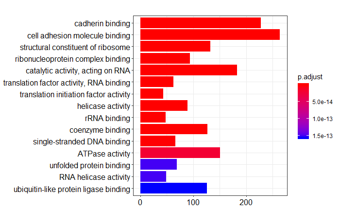

```r
barplot(ego_MF, showCategory=15)
```

```r
# cnetplot(ego_MF,categorySize="pvalue")


#Biological Process (BP):
#Cellular Component (CC):
#Molecular Function (MF):



# write Go data to csv files

write_csv(ego_BP_df,"go_biological.process.hela.csv")
write_csv(ego_CC_df,"go_cellular_component.hela.csv")
write_csv(ego_MF_df,"go_molecular_function.hela.csv")
```

Let’s look at Kegg over-representation

Let’s look at Kegg over-representation

```r
human <- search_kegg_organism('Homo sapiens', by='scientific_name') # find keg number for human

kk <- enrichKEGG(gene         = gene.df$ENTREZID,
                 organism     = 'hsa',
                 pvalueCutoff = 0.05)
head(kk)
```

|  | ID | Description | GeneRatio | BgRatio | pvalue | p.adjust | qvalue | geneID | Count |
| --- | --- | --- | --- | --- | --- | --- | --- | --- | --- |
| hsa03040 | hsa03040 | Spliceosome | 113/2032 | 135/7946 | 2.614369e-46 | 8.287549e-44 | 6.302005e-44 | 10915/23350/1665/9128/9092/10465/5356/8449/9716/51362/10772/…… | 113 |
| hsa03013 | hsa03013 | RNA transport | 121/2032 | 165/7946 | 1.755065e-38 | 2.781777e-36 | 2.115315e-36 | 8665/10284/10419/8664/8667/11260/9470/9631/10248/10799/8666/…… | 121 |
| hsa03010 | hsa03010 | Ribosome | 114/2032 | 153/7946 | 2.014460e-37 | 2.128613e-35 | 1.618636e-35 | 63931/6176/6181/6218/11222/6187/6165/6129/6139/6188/6206/613…… | 114 |
| hsa01200 | hsa01200 | Carbon metabolism | 76/2032 | 117/7946 | 2.043908e-19 | 1.619797e-17 | 1.231724e-17 | 283871/26227/3420/1431/3417/25796/2806/847/5096/2023/2271/52…… | 76 |
| hsa05016 | hsa05016 | Huntington disease | 101/2032 | 193/7946 | 8.288902e-16 | 5.255164e-14 | 3.996123e-14 | 4728/4697/4706/4709/4695/374291/4720/4726/4722/10476/161/470…… | 101 |
| hsa04141 | hsa04141 | Protein processing in endoplasmic reticulum | 90/2032 | 166/7946 | 1.875242e-15 | 9.907528e-14 | 7.533866e-14 | 10294/22872/10277/10427/22824/6184/6185/5034/823/9601/824/56…… | 90 |

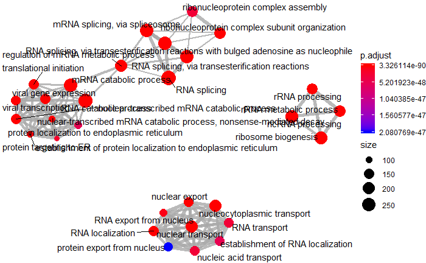

```r
# Enrichment map organizes enriched terms into a network with edges connecting overlapping gene sets. In this way, mutually overlapping gene sets are tend to cluster together, making it easy to identify functional module.

emapplot(ego_BP,pie_scale=1.5,layout="kk")
```

```r
NA
NA
```

```r
#WikiPathways

BiocManager::install("rWikiPathways")
library(rWikiPathways)

downloadPathwayArchive(organism="Homo sapiens",format="gmt") #download human wikipathway file
```

```
[1] "wikipathways-20191110-gmt-Homo_sapiens.gmt"
```

```r
wp2gene <- read.gmt("wikipathways-20191110-gmt-Homo_sapiens.gmt") #read downloaded file
wp2gene <- wp2gene %>% tidyr::separate(ont, c("name","version","wpid","org"), "%")
wpid2gene <- wp2gene %>% dplyr::select(wpid, gene) #TERM2GENE
wpid2name <- wp2gene %>% dplyr::select(wpid, name) #TERM2NAME

ewp <- enricher(geneList, TERM2GENE = wpid2gene, TERM2NAME = wpid2name)

head(ewp)
```

|  | ID | Description | GeneRatio | BgRatio | pvalue | p.adjust | qvalue | geneID | Count |
| --- | --- | --- | --- | --- | --- | --- | --- | --- | --- |
| WP477 | WP477 | Cytoplasmic Ribosomal Proteins | 82/1750 | 91/6851 | 3.755181e-39 | 1.648524e-36 | 1.296526e-36 | 9801/9349/9045/7311/6235/6234/6233/6232/6231/6230/6229/6228/…… | 82 |
| WP411 | WP411 | mRNA Processing | 101/1750 | 133/6851 | 1.261082e-34 | 2.768075e-32 | 2.177026e-32 | 9785/9584/9410/9343/9129/9128/8899/8732/8731/8683/84991/8484…… | 101 |
| WP4290 | WP4290 | Metabolic reprogramming in colon cancer | 38/1750 | 44/6851 | 2.903059e-17 | 4.248142e-15 | 3.341064e-15 | 9123/8801/7086/6888/6513/6510/6472/6390/5831/5723/5471/5315/5230/5226/5223/5211/5162/5160/50/47/4191/3939/3419/3418/29968/29920/2821/2806/2746/2744/2618/2597/2539/2271/2194/2023/1743/10606 | 38 |
| WP107 | WP107 | Translation Factors | 42/1750 | 54/6851 | 1.038063e-15 | 1.139274e-13 | 8.960122e-14 | 9669/8894/8893/8892/8891/8890/8669/8668/8667/8666/8665/8664/…… | 42 |
| WP111 | WP111 | Electron Transport Chain (OXPHOS system in mitochondria) | 64/1750 | 106/6851 | 2.359994e-14 | 2.072075e-12 | 1.629638e-12 | 9551/93974/9377/9167/7388/7385/7384/7381/6834/6391/6390/6389…… | 64 |
| WP4352 | WP4352 | Ciliary landscape | 107/1750 | 220/6851 | 5.903607e-14 | 4.319473e-12 | 3.397163e-12 | 9882/9859/9669/9343/9342/9318/9255/9217/9125/8826/8732/8655/…… | 107 |

```r
NA
NA
```

##Let’s do some Gene Ontology using clusterprofiler on the K562 sample!

```r
# load  msFragger data
# this is a 100 ng K562  run on the  timstofPRO using a 30 minute gradient
# Change this to the combined protein file if it's a multiexperiment

data <- read_tsv("protein.k562.tsv")
```

Looks like we identified 3294 proteins at a 1% FDR. Not bad for 1 run of 100 ng huh for a 30 minute gradient?

```r
library(org.Hs.eg.db) # this is for human. load a different library from here for a different speccies http://bioconductor.org/packages/release/BiocViews.html#___OrgDb


gene <- data$Gene # extract Gene's from MSFragger

# this translates the Gene from MSfragger to something enrichgo can read

gene.df <- bitr(gene, fromType = "SYMBOL",
        toType = "ENTREZID",
        OrgDb = org.Hs.eg.db)
```

```
1% of input gene IDs are fail to map...
```

```
wrong orderBy parameter; set to default `orderBy = "x"`
```

[figure not shown]

```r
# Make a geneList for some future functions

geneList <- gene.df$ENTREZID
names(geneList) <- as.character(gene.df$SYMBOL)
geneList <- sort(geneList, decreasing = TRUE)


# gene enrichment analysis cnplots are commented out as they look crazy with a large number of proteins

ego_BP <- enrichGO(gene          = gene.df$ENTREZID,
                OrgDb         = org.Hs.eg.db,
                ont           = "BP",
                pAdjustMethod = "BH",
                readable = TRUE,
                pvalueCutoff  = 0.01,
                qvalueCutoff  = 0.05)
ego_BP_df <-as.data.frame(ego_BP)

dotplot(ego_BP, showCategory=15)
```

[figure not shown]

```r
barplot(ego_BP, showCategory=15)
```

```
wrong orderBy parameter; set to default `orderBy = "x"`
```

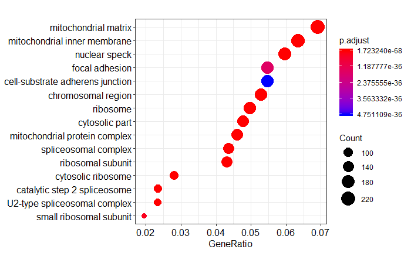

```r
# cnetplot(ego_BP,categorySize="pvalue")

ego_CC <- enrichGO(gene          = gene.df$ENTREZID,
                OrgDb         = org.Hs.eg.db,
                ont           = "CC",
                pAdjustMethod = "BH",
                readable = TRUE,
                pvalueCutoff  = 0.01,
                qvalueCutoff  = 0.05)
ego_CC_df <-as.data.frame(ego_CC)

dotplot(ego_CC, showCategory=15)
```

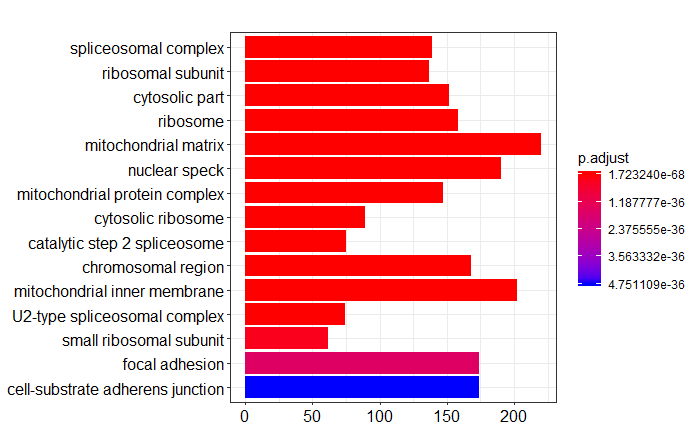

```r
barplot(ego_CC, showCategory=15)
```

```
wrong orderBy parameter; set to default `orderBy = "x"`
```

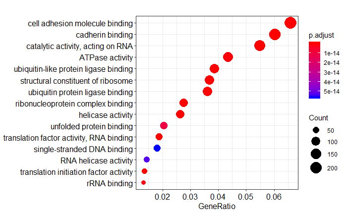

```r
# cnetplot(ego_CC,categorySize="pvalue")

ego_MF <- enrichGO(gene          = gene.df$ENTREZID,
                OrgDb         = org.Hs.eg.db,
                ont           = "MF",
                pAdjustMethod = "BH",
                readable = TRUE,
                pvalueCutoff  = 0.01,
                qvalueCutoff  = 0.05)
ego_MF_df <-as.data.frame(ego_MF)

dotplot(ego_MF, showCategory=15)
```

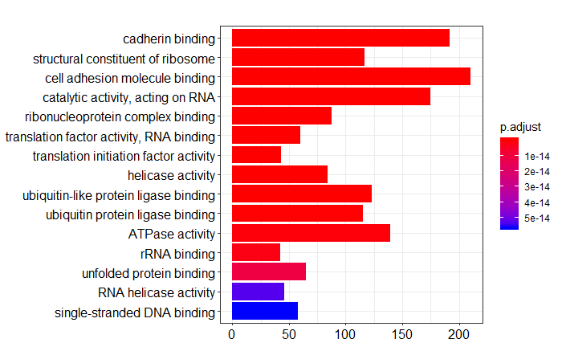

```r
barplot(ego_MF, showCategory=15)
```

```r
# cnetplot(ego_MF,categorySize="pvalue")


#Biological Process (BP):
#Cellular Component (CC):
#Molecular Function (MF):



# write Go data to csv files

write_csv(ego_BP_df,"go_biological.process.k562.csv")
write_csv(ego_CC_df,"go_cellular_component.k562.csv")
write_csv(ego_MF_df,"go_molecular_function.k562.csv")
```

Let’s look at Kegg over-representation

```r
human <- search_kegg_organism('Homo sapiens', by='scientific_name') # find keg number for human

kk <- enrichKEGG(gene         = gene.df$ENTREZID,
                 organism     = 'hsa',
                 pvalueCutoff = 0.05)
head(kk)
```

|  | ID | Description | GeneRatio | BgRatio | pvalue | p.adjust | qvalue | geneID | Count |
| --- | --- | --- | --- | --- | --- | --- | --- | --- | --- |
| hsa03040 | hsa03040 | Spliceosome | 110/1707 | 135/7946 | 7.671816e-51 | 2.378263e-48 | 1.889689e-48 | 10915/23350/1665/9128/9092/9129/10465/5356/9716/10772/23451/…… | 110 |
| hsa03013 | hsa03013 | RNA transport | 117/1707 | 165/7946 | 6.316094e-43 | 9.789946e-41 | 7.778769e-41 | 8665/10284/9086/10419/7514/8664/8667/11260/10289/9669/9631/1…… | 117 |
| hsa03010 | hsa03010 | Ribosome | 98/1707 | 153/7946 | 2.302955e-30 | 2.379721e-28 | 1.890848e-28 | 6176/6181/6218/3921/6187/6129/6139/6188/6206/6137/6136/6133/…… | 98 |
| hsa01200 | hsa01200 | Carbon metabolism | 70/1707 | 117/7946 | 1.493771e-19 | 1.157673e-17 | 9.198488e-18 | 283871/26227/3420/1431/3417/25796/847/2597/2821/2271/5213/17…… | 70 |
| hsa03050 | hsa03050 | Proteasome | 38/1707 | 45/7946 | 2.720401e-19 | 1.686649e-17 | 1.340155e-17 | 5717/5718/10213/5709/5702/5689/5682/5683/5684/5685/5686/5692/5694/5693/5701/5704/5714/5691/5690/5713/5687/10197/5700/5705/5706/5720/5708/9861/11047/9491/5695/5707/5721/5719/51371/5688/5710/23198 | 38 |
| hsa03008 | hsa03008 | Ribosome biogenesis in eukaryotes | 63/1707 | 105/7946 | 8.278187e-18 | 4.277064e-16 | 3.398414e-16 | 10199/10528/7514/4931/1736/10799/1459/4809/3692/5901/1460/14…… | 63 |

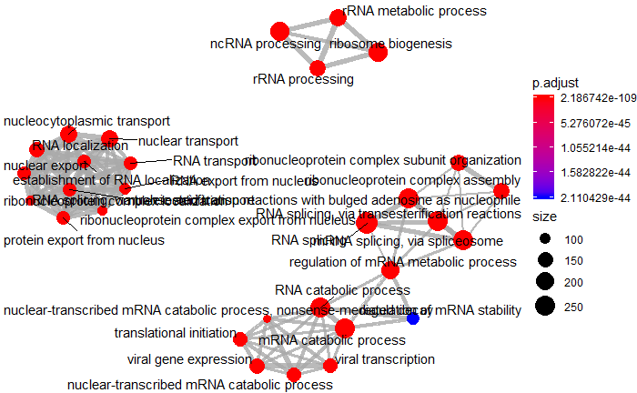

```r
# Enrichment map organizes enriched terms into a network with edges connecting overlapping gene sets. In this way, mutually overlapping gene sets are tend to cluster together, making it easy to identify functional module.

emapplot(ego_BP,pie_scale=1.5,layout="kk")
```

```r
NA
NA
```

```r
#WikiPathways

BiocManager::install("rWikiPathways")
library(rWikiPathways)

downloadPathwayArchive(organism="Homo sapiens",format="gmt") #download human wikipathway file
```

```
[1] "wikipathways-20191110-gmt-Homo_sapiens.gmt"
```

```r
wp2gene <- read.gmt("wikipathways-20191110-gmt-Homo_sapiens.gmt") #read downloaded file
wp2gene <- wp2gene %>% tidyr::separate(ont, c("name","version","wpid","org"), "%")
wpid2gene <- wp2gene %>% dplyr::select(wpid, gene) #TERM2GENE
wpid2name <- wp2gene %>% dplyr::select(wpid, name) #TERM2NAME

ewp <- enricher(geneList, TERM2GENE = wpid2gene, TERM2NAME = wpid2name)

head(ewp)
```

|  | ID | Description | GeneRatio | BgRatio | pvalue | p.adjust | qvalue | geneID | Count |
| --- | --- | --- | --- | --- | --- | --- | --- | --- | --- |
| WP411 | WP411 | mRNA Processing | 106/1496 | 133/6851 | 1.112256e-46 | 4.693722e-44 | 3.922167e-44 | 9785/9584/9410/9343/9129/9128/8899/8731/8683/84991/84844/844…… | 106 |
| WP477 | WP477 | Cytoplasmic Ribosomal Proteins | 76/1496 | 91/6851 | 2.214103e-36 | 4.671757e-34 | 3.903813e-34 | 9349/9045/7311/6235/6234/6233/6232/6231/6230/6229/6228/6227/…… | 76 |
| WP107 | WP107 | Translation Factors | 43/1496 | 54/6851 | 1.741209e-19 | 2.449300e-17 | 2.046684e-17 | 9669/9086/8894/8893/8892/8891/8890/8669/8668/8667/8666/8665/…… | 43 |
| WP4290 | WP4290 | Metabolic reprogramming in colon cancer | 36/1496 | 44/6851 | 3.181447e-17 | 3.356426e-15 | 2.804697e-15 | 8801/7086/6888/6513/6510/6472/6390/5831/5471/5315/5230/5226/5223/5211/5162/5160/50/47/4191/3939/3419/3418/29968/29920/2821/2746/2744/2618/2597/2539/22934/2271/2194/2023/1743/10606 | 36 |
| WP4352 | WP4352 | Ciliary landscape | 103/1496 | 220/6851 | 5.783992e-17 | 4.881689e-15 | 4.079236e-15 | 9859/9669/9343/9342/9318/9255/9217/9125/8826/8655/85456/8533…… | 103 |
| WP183 | WP183 | Proteasome Degradation | 44/1496 | 64/6851 | 9.278242e-16 | 6.525697e-14 | 5.453002e-14 | 9861/7347/7323/7320/7317/6185/6184/5721/5720/5719/5718/5717/…… | 44 |

```r
NA
NA
```